# Calibration

## Reviewing weights

Imagine you’re conducting a survey of the DMV area, but you take an equal sized sample from each state.

| State | Pop Size | Sample size |
| --- | --- | --- |
| DC | 693,645 | 1,000 |
| Maryland | 6,265,347 | 1,000 |
| Virginia | 8,880,107 | 1,000 |
| Total | 15,839,099 | 3,000 |

How should you re-weight this if the goal is to analyze the overall views of people in the DMV area?

## Reviewing weights

Dividing the population size by the sample size will give you weights that equal the inverse probability of selection:

| State | Pop Size | Sample Size | Weight 1 |
| --- | --- | --- | --- |
| DC | 693,645 | 1,000 | 693.645 |
| Maryland | 6,265,347 | 1,000 | 6265.347 |
| Virginia | 8,880,107 | 1,000 | 8880.107 |
| Total | 15,839,099 | 3,000 | 15839.099 |

Note that applying these weights to each person would give you a total sum of 15,839,099

## Reviewing weights

More often, weights will be normalized so they sum to the total number of observations in the sample. The exact values here are less important than the *ratios* between the weights for each group.

| State | Pop Size | Sample Size | Weight 1 |
| --- | --- | --- | --- |
| DC | 693,645 | 1,000 | 0.13 |
| Maryland | 6,265,347 | 1,000 | 1.19 |
| Virginia | 8,880,107 | 1,000 | 1.68 |
| Total | 15,839,099 | 3,000 | 3.00 |

Note that summing these weights for each respondent would now give you a total of 3,000.

## Reviewing weights

More often, weights will be normalized so they sum to the total number of observations in the sample. The exact values here are less important than the *ratios* between the weights for each group.

| State | Pop Size | Sample Size | Weight 1 |
| --- | --- | --- | --- |
| DC | 693,645 | 1,000 | 0.13 |
| Maryland | 6,265,347 | 1,000 | 1.19 |
| Virginia | 8,880,107 | 1,000 | 1.68 |
| Total | 15,839,099 | 3,000 | 3.00 |

Note that summing these weights for each respondent would now give you a total of 3,000.

## Reviewing weights

Note that response rates here might differ, meaning that our resulting survey no longer resembles the population.

|  | Pop Size | Sample Size | Repondents | Response Rate | Weight 1 |
| --- | --- | --- | --- | --- | --- |
| DC |  |  |  |  |  |
| Total | 693,645 | 1,000 | 888 | 0.888 | 0.13 |
| Hispanic | 83,237 | 120 | 96 | 0.800 | - |
| Non-hispanic | 610,408 | 880 | 792 | 0.900 | - |
| Maryland |  |  |  |  |  |
| Total | 6,265,347 | 1,000 | 887 | 0.887 | 1.19 |
| Hispanic | 814,495 | 130 | 104 | 0.800 | - |
| Non-hispanic | 5,450,852 | 870 | 783 | 0.900 | - |
| Virginia |  |  |  |  |  |
| Total | 8,880,107 | 1,000 | 889 | 0.889 | 1.68 |
| Hispanic | 976,812 | 110 | 88 | 0.800 | - |
| Non-hispanic | 7,903,295 | 890 | 801 | 0.900 | - |
| DMV |  |  |  |  |  |
| Total | 15,839,099 | 3,000 | 2664 | 0.888 | 3.00 |

## Reviewing weights

We can weight for non-response by taking $1/\rho_i$ where $\rho_i$ is the response rate for group i.

|  | Pop Size | Sample Size | Repondents | Response Rate | Weight 1 | Weight 2 |
| --- | --- | --- | --- | --- | --- | --- |
| DC |  |  |  |  |  |  |
| Total | 693,645 | 1,000 | 888 | 0.888 | 0.13 | 1.13 |
| Hispanic | 83,237 | 120 | 96 | 0.800 | - | 1.25 |
| Non-hispanic | 610,408 | 880 | 792 | 0.900 | - | 1.11 |
| Maryland |  |  |  |  |  |  |
| Total | 6,265,347 | 1,000 | 887 | 0.887 | 1.19 | 1.13 |
| Hispanic | 814,495 | 130 | 104 | 0.800 | - | 1.25 |
| Non-hispanic | 5,450,852 | 870 | 783 | 0.900 | - | 1.11 |
| Virginia |  |  |  |  |  |  |
| Total | 8,880,107 | 1,000 | 889 | 0.889 | 1.68 | 1.12 |
| Hispanic | 976,812 | 110 | 88 | 0.800 | - | 1.25 |
| Non-hispanic | 7,903,295 | 890 | 801 | 0.900 | - | 1.11 |
| DMV |  |  |  |  |  |  |
| Total | 15,839,099 | 3,000 | 2664 | 0.888 | 3.00 | 1.13 |

## Reviewing weights

Multiple weights can be combined multiplicatively:

[output not shown]

## Additional adjustments

What happens if you *still* see a discrepancy between the sample and the population even after you’ve adjusted for different probabilities of selection and non-response?

Possible reasons:

- Random sampling error
- Coverage error
- Non-response not fully accounted for by non-response adjustment

## Calibration

Calibrations are additional adjustments made to a survey after collection usually to force a sample to resemble a “benchmark” population total.

The basic adjustment is simple: if women are 51% of the target population but 50% of our sample, then we would give them a weight of $.51/.50 = 1.02$ (and men would get a weight of $.98$)

Then we would multiply these with our other weights to get a final calibrated weight.

## Sources of auxiliary information

- Those benchmarks need to be reliable estimates of the population values. The Census and American Community Survey (ACS) are two widely used sources.

## Calibration for multiple variables

What if we wanted to adjust for gender, ethnicity, education, age, and urban/rural residence?

## Calibration with raking

Raking (or iterative proportional fitting) is a method of calibration that only requires marginal totals.

- Each calibration variable is weighted separately, one at a time.
- This process is repeated until the weights (hopefully) stabilize.
- Usually, weights with extreme values are “trimmed”, which trades some bias for reduced sampling variance.

## Calibration with raking

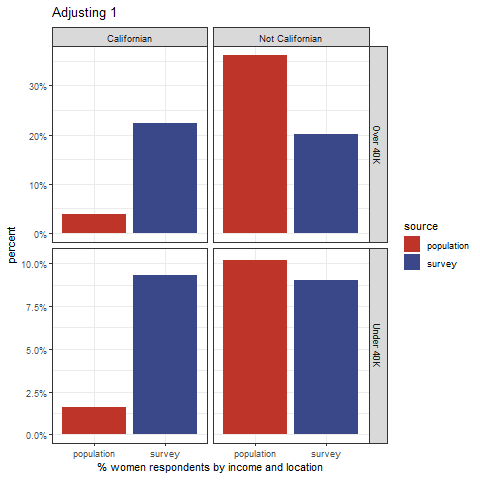

## Calibration with raking

One advantage of raking is that it makes it possible to use auxiliary data from multiple sources: measures of age from the census can be combined with measures of voter registration, employment, or health habits all from totally different surveys.

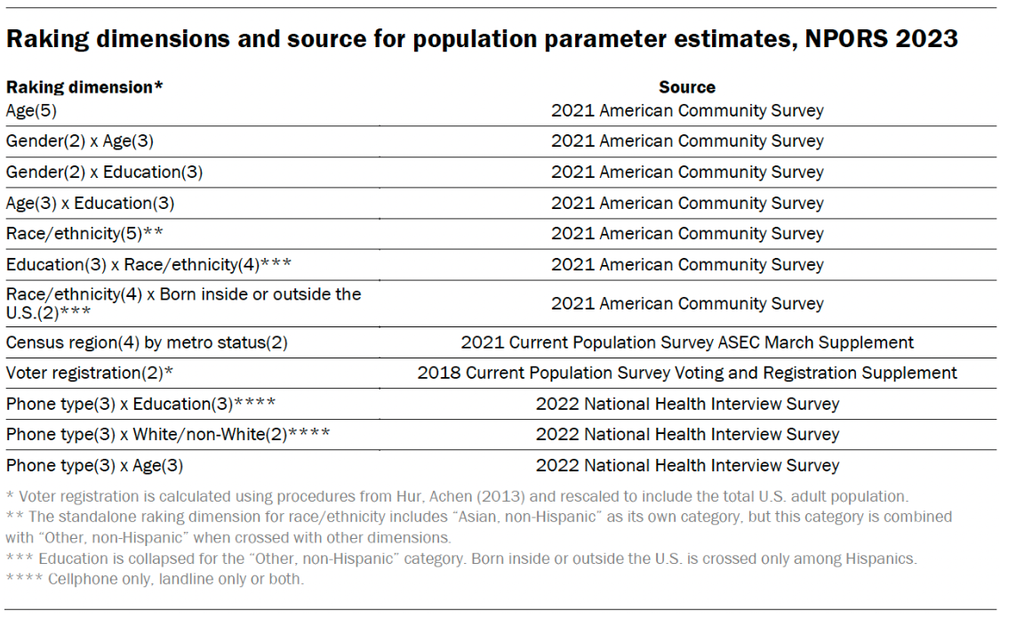

[NPORS 2023 Raking variables](https://www.pewresearch.org/internet/2024/01/31/social-media-2023-national-public-opinion-reference-survey-npors-methodology/)

## Post-stratification

- If we do have data on the joint distributions of all the variables, and we have sufficient data for each category, we can post-stratify instead.

## Multilevel Regression with Post-stratification

MRP used for:

- Adjusting highly non-representative surveys (such as online opt-in polls)
- Small area estimation (using a national poll to make an inference about a state)

## Multilevel Regression with Post-stratification

Basic process:

- Use survey results to model individual-level predictive model of public opinion for different subgroups (e.g., predicted voted choice for a college educated white woman in Michigan)
- Generate weighted predictions based on the known frequency of those subgroups in the target population.
- Multilevel modeling is used in the first step to handle the problem of having limited or no data for certain combinations of predictors. (where data are limited, multilevel models shrink estimates toward the grand mean)

## Multilevel Regression with Post-stratification

- [Gelman et al. (2016)] used an online opt-in poll of Xbox Live players to predict vote intentions in the 2012 election.
- MRP adjusted estimates closely tracked the national polls. (Raking wasn’t able to achieve this level of accuracy)

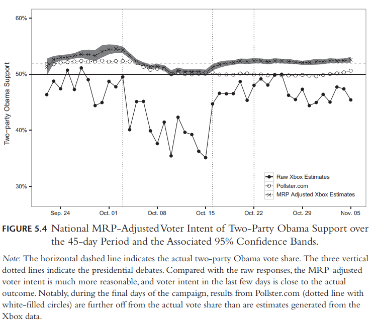

https://sites.stat.columbia.edu/gelman/research/published/high_frequency_polling.pdf

## Multilevel Regression with Post-stratification

- MRP requires building a model for every survey question, and it requires joint (not marginal) distributions for the values in the target population.
- We don’t have good data on some of the most important predictors, so MRP mostly relies on demographic data.

# References

Gelman, Andrew, Sharad Goel, David Rothschild, and Wei Wang. 2016. “High-Frequency Polling with Non-Representative Data.” In *Political Communication in Real Time*. Routledge.